# Stan de BridgeSampling -BayesFactorで拡がる心理学-

Stan Advent Calender 2017 12 21

## はじめに

- この記事は､[Stan Advent Calender 2017](https://qiita.com/advent-calendar/2017/stan)の21日目の記事になります｡Advent calenderもいよいよあと5日でゴールですね!!
- どうも､Hojo Daikiと申します｡[お前､誰やねん→HPに行く](https://dastatis.github.io/index.html)

### 記事に関する注意

- Bayes Factor(BF) は､モデル評価の1つの指標でしかありません｡**BFのみでモデルの善し悪しを完全に評価することはできません｡**とりあえず､従来のp値の代わりにつかっとけばいいや､という指標ではないことを念頭にご覧下さい｡あくまでも､StanでBFが算出できるようになったー!やったー!って感じです｡
- 間違ってたら教えてね｡てへぺろ☆(・ω<)

## ベイズファクターとは??

いきなりですが､今日が何の日かわかりますか…?  
1年で2回しかない**｢べいずふぁくたーの日｣**ですよ!!  
10/01が今年一回目の｢べいずふぁくたーの日**(秋)**｣で  
そして､本日､12/21が今年二回目にして､最後の｢べいずふぁくたーの日**(冬)**｣です｡

ということで､今日はベイズファクターのお話をしましょう｡

Bayes Factorは､ベイズファクター､ベイズ因子(因数)と呼ばれます｡  
ここまでグルメ記事だと思って､この記事を読まれていたらすみません｡  
ベイズファクターは食べ物ではありません｡  
じゃあ､ベイズファクターって何なの?  
ということで､困ったらまずwikiをみよう()｡

[figure not shown]

[(wiki)](https://ja.wikipedia.org/wiki/%E3%83%99%E3%82%A4%E3%82%BA%E5%9B%A0%E5%AD%90)

なるほど…さっぱりわからん｡  
よし､じゃあ順番に考えていこう｡

パラメータ推定の文脈において､我々は興味のあるパラメータ$\theta$の不確かさを観測データ$y$から求めるとき
$$\begin{equation}
p(\theta|y)=\frac{p(y|\theta)p(\theta)}{p(y)}
\end{equation}$$

と表される｡  
このとき､$p(\theta|y)$は事後分布､$p(y|\theta)$は尤度､$p(\theta)$は事前分布｡そして､$p(y)$は周辺尤度である｡これは､普通のベイズの定理ですね｡

次にモデル比較の文脈で考えてみます｡
ベイズではデータ$y$が与えられたときに特定の($i$番目の)モデル$M_i$が起きる確率(事後モデル確率)を検討することができるので､､､
$m$個の候補モデルがあり､データ$y$が与えられたときの$i$番目のモデル事後確率は､
$$\begin{equation}
p(M_i|y) = \frac{p(y|M_i)p(M_i)}{p(y)}
= \frac{p(y|M_i)p(M_i)}{\Sigma^m_{j=1}p(y|M_j)p(M_j)}
\end{equation}$$
と表せる｡
つまり､言葉で書くと､､､
$$\begin{equation}
事後モデル確率 = \frac{周辺尤度\times事前モデル確率}{候補すべての(周辺尤度\times事前モデル確率)}
\end{equation}$$

とも書くことができる｡  
ここで重要な点として､この式の周辺尤度$p(y|M_i)$とパラメータ推定での式の分母の周辺尤度$p(y)$が一致するということ｡

なぜ､一致するのか?  
→パラメータ推定であっても特定のモデル($M_i$)下であるということは変わらないので､特定のモデル下における周辺尤度と考えることができる(つまり､$p(y)=p(y|M_i)$みたいな感じ)｡

ここからは､例として､$m=2$(候補のモデルが2つ)の状況について考えてみる｡
先ほどの数式における1つ目のモデルの事後確率($m=1$)は､
$$\begin{equation}
p(M_1|y) = \frac{p(y|M_1)p(M_1)}{\Sigma^m_{j=1}p(y|M_j)p(M_j)}
\end{equation}$$
と表される｡
では､2つ目のモデルの事後確率($m=2$)は､
$$\begin{equation}
p(M_2|y) = \frac{p(y|M_2)p(M_2)}{\Sigma^m_{j=1}p(y|M_j)p(M_j)}
\end{equation}$$
と表される｡
ここで､この2つの式の分母は､同じなので､2つの式を合わせてみると…
$$\begin{equation}
\frac{p(M_1|y)}{p(M_2|y)} = \frac{p(y|M_1)}{p(y|M_2)} \times \frac{p(M_1)}{p(M_2)}
\end{equation}$$
と表現できる｡
おおー!!つまり､これってオッズだよね?
言葉で解釈すると･･･
$$\begin{equation}
事後オッズ = 各モデルの周辺尤度の比 \times 事前オッズ
\end{equation}$$

ってこと｡  
ここでの､事後オッズおよび事前オッズは､正確には｢事後(事前)モデル確率のオッズ｣をさします｡  
そして､ようやくベイズファクターが登場!! この式の各モデルの周辺尤度の比をベイズファクターを呼ぶ｡

これを整理すると､ベイズファクターは､
$$\begin{equation}
ベイズファクター = \frac{事後オッズ}{事前オッズ}
\end{equation}$$
と表現できる｡
数式だと､､､
$$\begin{equation}
BF_{12} = \frac{p(y|M_1)}{p(y|M_2)} = \frac{\frac{p(M_1|y)}{p(M_2|y)}}{\frac{p(M_1)}{p(M_2)}}
\end{equation}$$

になる｡  
つまり､$BF_{12}$は､データによって与えられたモデル$M_2$に比してモデル$M_1$を支持する程度(オッズ)の変化を表すことになります｡

## ベイズファクターの問題点

これまで多くの研究者がベイズファクターについて次のように語っている｡  
ある者は､  
**“standard Bayesian solution to the hypothesis testing and model selection problems”**

(Lewis & Rftery, 1997, p648)

また､ある者は､  
**“the primary tool used in Bayesian inference for hypothesis testing and model selection”**

(Berger, 2006, p.378)

つまり､ベイズファクターは､ベイズの定理を基に導出されるベイズ推定における最も“順当な”モデル選択の道具と主張されることもある｡  
(何度も書くが､ベイズファクターがベイズ統計のモデル評価の全てではない｡)

**では､なぜベイズファクターがあまり用いられないのだろうか??**  
様々な問題はあるが、複雑なモデルでベイズファクターの導出が困難なことが最も大きな問題でしょう｡  
使わないというより､使えないってのが大きい｡

使うことができない原因は何か? →多重積分の問題である。

※多重積分ってなに? →簡単にいえば､積分を何度もすることである｡  
高2のこの時期に手計算して苦しんだ､あの積分の問題をめちゃくちゃ解かなければいけないことになる｡  
多重積分ワッショイ✌︎(‘$\omega$’✌︎ )$\iiint\iiint\iiint$( ✌︎‘$\omega$’)✌

**どんなケースでベイズファクターを(容易に)算出できない?**  
- 非線形モデル  
- パラメータ数が多いモデル(e.g., 階層モデル)  
→ むしろ､ベイズファクターを計算できるモデルを探す方が早いのでは??

**ということは､結局､ベイズファクターは簡単に算出できないのだろうか?**

## MCMCを用いたベイズファクター(周辺尤度)の近似方法

思い出してほしい｡我々(一般人)は､常日頃､一体何をしているのか?

とある一般人のTwitterの様子

[figure not shown]

そう､ここからもわかるように､我々(一般ピープル)はMCMCをして生きている｡

[figure not shown]

※一体何の会議をしているのだろう…

つまり､**MCMCは世界を救うのだ**(周辺尤度に近似させることができるのだ)｡  
そして､以下が､これまで提案されてきたMCMCを用いて周辺尤度を近似させる方法(一部)である｡  
- Naive Monte Carlo Estimator  
- Importance Sampling Estimator (重点サンプリング法)  
- Generalized Harmonic Mean Estimator (一般化調和平均法??)  
- Bridge Sampling (ブリッジサンプリング)

前置きが長くなってしまったが､ ここからは上記の手法を説明する…はずだった｡←えっ  
多忙で､そこまで手が回らなかったので｡｡｡  
くわしくは[下↓](https://www.slideshare.net/daikihojo/bridgesampling)に別の勉強会の資料をうpしたので9スライド目からご覧下さい｡

[interactive chart not shown]

**[あなたの心にBridgeSampling](https://www.slideshare.net/daikihojo/bridgesampling)** from **[daiki hojo](https://www.slideshare.net/daikihojo)**

じゃあ､もう説明は済んだし､いきなり実践します｡(おい

## Stan de ベイズファクターいきなり3分クッキング

Stan de ベイズファクターいきなり3分クッキングへようこそ

本日のお品書き  
- t検定でベイズファクターを算出

[こちら](https://htmlpreview.github.io/?https://github.com/quentingronau/bridgesampling/blob/master/inst/doc/bridgesampling_stan_ttest.html)を参考にt検定でベイズファクターを算出してみます｡

まずは[パッケージ](https://github.com/quentingronau/bridgesampling)を用意します｡

```r
# CRANからインストール
install.packages("bridgesampling")

# GitHubから最新版をインストール(上級者向け)
devtools::install_github("quentingronau/bridgesampling@master")
```

つぎに､[パッケージ](https://github.com/quentingronau/bridgesampling)とデータを読み込みます｡

```r
# パッケージ読み込み
library(rstan)
library(bridgesampling)

# データ読み込み
data("sleep")
sleep
```

```
#>    extra group ID
#> 1    0.7     1  1
#> 2   -1.6     1  2
#> 3   -0.2     1  3
#> 4   -1.2     1  4
#> 5   -0.1     1  5
#> 6    3.4     1  6
#> 7    3.7     1  7
#> 8    0.8     1  8
#> 9    0.0     1  9
#> 10   2.0     1 10
#> 11   1.9     2  1
#> 12   0.8     2  2
#> 13   1.1     2  3
#> 14   0.1     2  4
#> 15  -0.1     2  5
#> 16   4.4     2  6
#> 17   5.5     2  7
#> 18   1.6     2  8
#> 19   4.6     2  9
#> 20   3.4     2 10
```

差得点の算出とサンプルサイズを定義(用意)します(先にモデルを見たほうがわかりやすいかもしれません)｡

```r
# ｢sleepデータのextra列におけるsleepデータのgruop列が2のデータ｣から
# ｢sleepデータのextra列におけるsleepデータのgruop列が1のデータ｣を引いたものを
# yという入れもの(オブジェクト)に入れている｡
y <- sleep$extra[sleep$group == 2] - sleep$extra[sleep$group == 1]

# サンプルサイズを定義(用意)する作業 yの長さ(length)を数えてあげる
n <- length(y)
```

次に､Stanモデルの記述を行います｡  
Stan de ベイズファクターを算出する上で大事なことは2つ｡  
- target += 記法で書くこと｡  
- warmup後にいつもより多めにサンプリングすること｡

通常､Stanで見慣れた書き方は､$y\sim normal(mu,1)$のような記法が多いと思います｡  
このように書くと､簡単にいえば計算を速くするために､定数項を除いて計算を行っています｡  
しかし､周辺尤度を計算する上では､こちらも必要になるので､それをしっかりと計算してくれるtarget += 記法でStanコードを書き直す必要があります｡  
target += 記法は以下のような書き方をすることをさします｡  
$y\sim normal(mu,1)$は､target += normal_lpdf(y|mu,1)と書き直してあげることになります｡

※この辺の詳しい話は､[Stan Manual](http://mc-stan.org/users/documentation/)もしくは､[松浦先生のStan本の4.3節](https://www.amazon.co.jp/exec/obidos/ASIN/4320112423/statmodeling-22/)に載っています｡

では､話をt検定モデルに戻します｡ 以下は､target+=記法で記述したt検定モデルです｡

```r
# models
H0model <- "
// 先ほどのURL先のモデルをそのまま引用
// H0 Model
data {
  int<lower=1> n; // サンプルサイズ
  vector[n] y; // 観測データ
}
parameters {
  real<lower=0> sigma2; // 分散パラメータ
}
model {
  target += log(1/sigma2); // Jeffreys prior on sigma2
  target += normal_lpdf(y | 0, sqrt(sigma2)); // likelihood
  // ベイズファクターを算出するときの重要なポイントは､
  // 尤度と事前分布を target += 記法で記述すること｡
}
"
H1model <- "
data {
  // 先ほどのURL先のモデルをそのまま引用
  // H1 Model
  int<lower=1> n; // サンプルサイズ
  vector[n] y; // 観測データ
  real<lower=0> r; // コーシー分布のスケール
}
parameters {
  real delta;
  real<lower=0> sigma2;// 分散パラメータ
}
model {
  target += cauchy_lpdf(delta | 0, r); // Cauchy prior on delta
  target += log(1/sigma2); // Jeffreys prior on sigma2
  target += normal_lpdf(y | delta*sqrt(sigma2), sqrt(sigma2));  // likelihood
  // ベイズファクターを算出するときの重要なポイントは､
  // 尤度と事前分布を target += 記法で記述すること｡
}
"

# モデルのコンパイル
H0model <- stan_model(model_code = H0model, model_name = "H0model")
H1model <- stan_model(model_code = H1model, model_name = "H1model")
```

そして､MCMC(;´Д`)ﾊｧﾊｧを行います｡  
ここで､Stan de ベイズファクターを算出する上での重要な点2つ目です｡  
それは､通常よりも多めのサンプリングを行うこと｡  
なので、今回はiterationを20000回のwarmupを1000回にしています。

```r
## 帰無仮説モデルのMCMC
fitH0 <- sampling(H0model, data = list(y = y, n = n), iter = 20000, warmup = 1000,
    chains = 4, cores = 4, control = list(adapt_delta = 0.99))

## 対立仮説モデルのMCMC
fitH1 <- sampling(H1model, data = list(y = y, n = n, r = 1/sqrt(2)), iter = 20000,
    warmup = 1000, chains = 4, cores = 4, control = list(adapt_delta = 0.99))
```

Stanの結果を確認する｡  
詳しい事後処理は､[昨年の資料](https://www.slideshare.net/daikihojo/stan-70425025)を参照して下さい(宣伝)

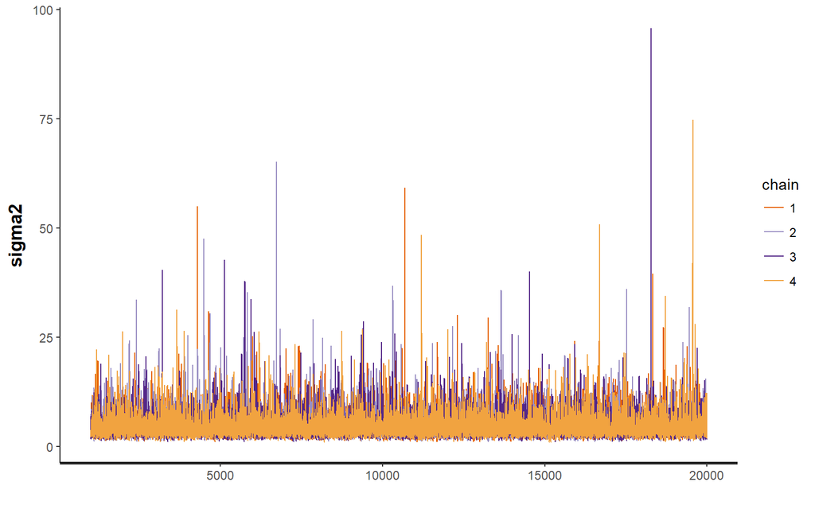

```r
## trace plot
stan_trace(fitH0)
```

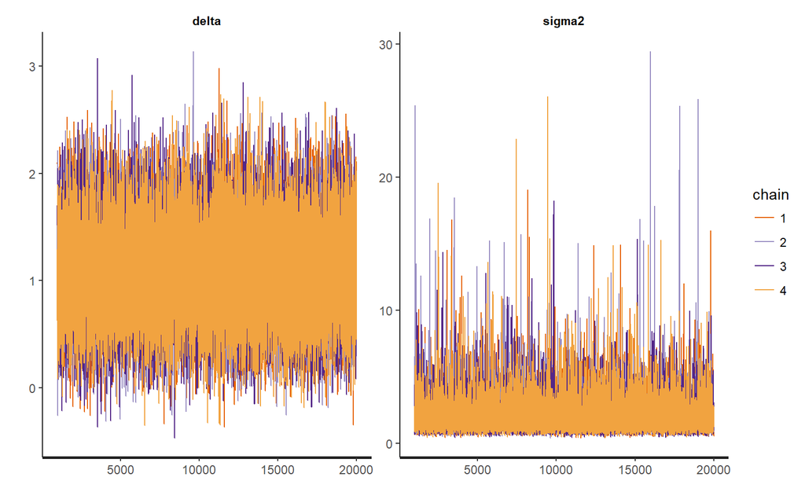

```r
stan_trace(fitH1)
```

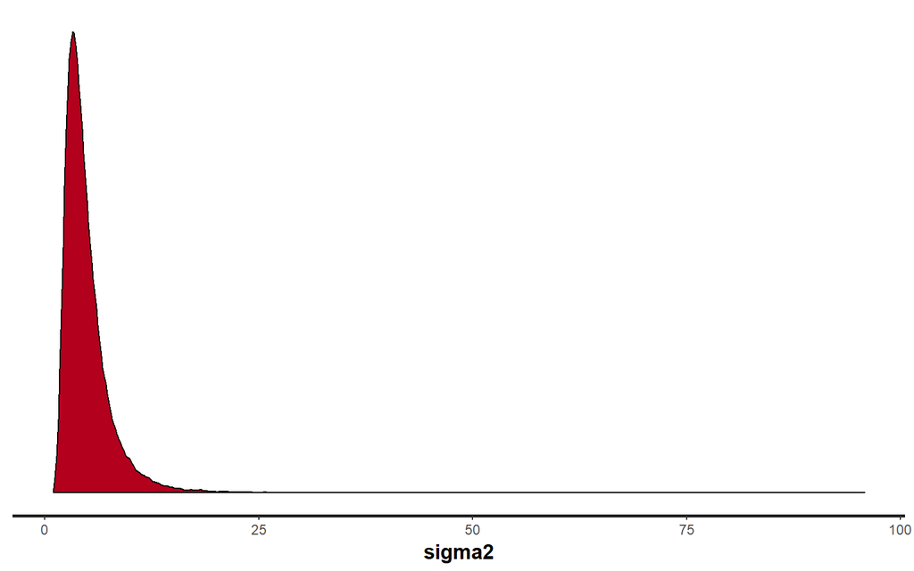

```r
## density plot
stan_dens(fitH0)
```

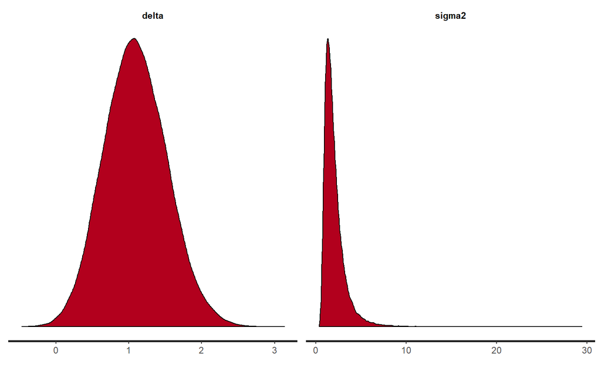

```r
stan_dens(fitH1)
```

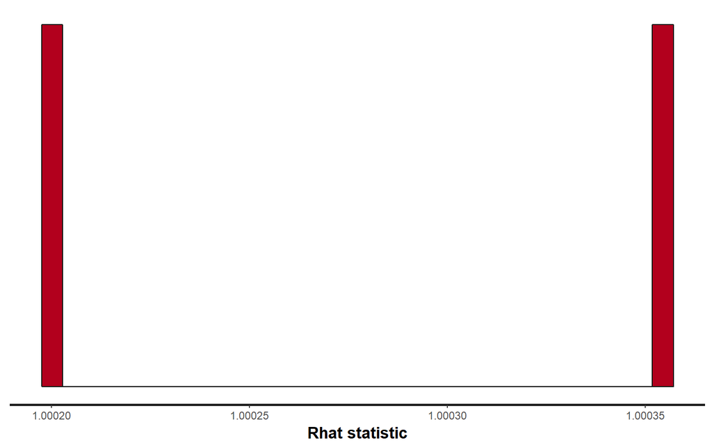

```r
## Rhat
stan_rhat(fitH0)
```

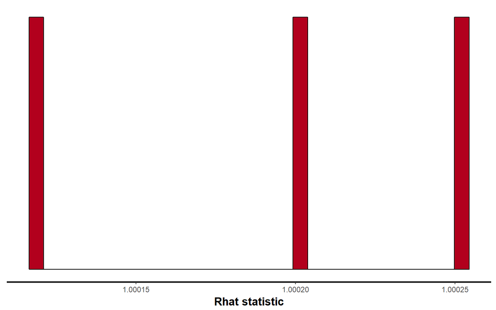

```r
stan_rhat(fitH1)
```

そしたら､Stanオブジェクトを用いて､BridgeSamplingで周辺尤度を近似します｡  
どーん!!!

```r
## Seed値の設定
set.seed(12345)

## Stan結果オブジェクトを用いて､Bridge
## Samplingを行い､周辺尤度を近似する｡(デフォルトは､通常のBridgeSampling(method='normal')を実施)
## もし､WARP-IIIアルゴリズムで計算したければ､method='WARP'を使う｡
## silentのオプションは計算過程を表示するか否か
H0 <- bridge_sampler(fitH0, method = "normal", silent = TRUE)
print(H0)
```

```
#> Bridge sampling estimate of the log marginal likelihood: -20.80943
#> Estimate obtained in 5 iteration(s) via method "normal".
```

```r
H1 <- bridge_sampler(fitH1, method = "normal", silent = TRUE)
print(H1)
```

```
#> Bridge sampling estimate of the log marginal likelihood: -17.96112
#> Estimate obtained in 4 iteration(s) via method "normal".
```

```r
# compute percentage errors
print(error_measures(H0)$percentage)
```

```
#> [1] "0.0501%"
```

```r
print(error_measures(H1)$percentage)
```

```
#> [1] "0.0647%"
```

いよいよベイズファクターを算出します｡  
やり方は簡単､bf()関数に今計算した周辺尤度を入れてあげればOKです  
どーん!!!

```r
BF10 <- bf(H1, H0)
print(BF10)
```

```
#> The estimated Bayes factor in favor of x1 over x2 is equal to: 17.25862
```

※BFの値にも基準があり､それ以上であれば効果量が大きいとの判断がされることがあります｡  
しかし､それをここに載せると､p値を0.5にするか0.05にするのかのようなつまらない議論が始まるので載せません｡  
詳しくはググって下さい｡BFはあくまでもモデル比較の一つの指標です｡

## ベイズファクターの注意点

以降は､注意点です｡  
- ベイズファクターは事前分布の影響をかなり大きくうけます ｡  
→ 同一データ､同一モデルで事前分布のみを変化させた場合に､どれだけベイズファクターが変化するかを検討するととてもよくわかります｡  
- bridgesamplingパッケージでも計算がうまく行かないことはありますので､全てのモデル間のベイズファクターが計算できるわけではありません｡  
- モデル比較を行うのはとても難しいです｡本来､我々が､比較すべきモデルは無限に存在します｡  
- ベイズファクターは､2つのモデル間の比として考えるので､それ以外のモデルについては考えてはいません｡

ただ､ベイズファクターは､今後の心理学研究に様々な“良いこと”をもたらしてくれると思います｡  
本当は､もう少しお話をしたかったのですが､それはまた別の機会にしましょう｡

長い文章でしたが､ご精読ありがとうございました｡

**Enjoy!!!**

## 引用･参考文献(上の文献ほどよく引用･参考にしています)

```
- Gronau, Q. F., Sarafoglou, A., Matzke, D., Ly, A., Boehm, U., Marsman, M., ... & Steingroever, H. (2017). A tutorial on bridge sampling. arXiv preprint arXiv:1703.05984v2.
- Gronau, Q. F., Wagenmakers, E. J., Heck, D. W., & Matzke, D. (2017). A Simple Method for Comparing Complex Models: Bayesian Model Comparison for Hierarchical Multinomial Processing Tree Models using Warp-III Bridge Sampling.
- Wang, L., & Meng, X. L. (2016). Warp bridge sampling: the next generation. arXiv preprint arXiv:1609.07690.
- Meng, X. L., & Schilling, S. (2002). Warp bridge sampling. Journal of Computational and Graphical Statistics, 11(3), 552-586.
- Lewis, S. M., & Raftery, A. E. (1997). Estimating Bayes factors via posterior simulation with the Laplace—Metropolis estimator. Journal of the American Statistical Association, 92(438), 648-655.
- Berger, J. O. (2006). Bayes factors. Encyclopedia of statistical sciences.
- ベイジアンの皆様の技術ブログ等々
```

Daiki Hojo @dastatis

2017-12-21